# 时间序列

zhutx

2016/3/1

# 时间序列入门

## 读取数据

读取英格兰连续42位君主的离世年纪所构成的时间序列

```r
kings <- scan("http://robjhyndman.com/tsdldata/misc/kings.dat", skip=3)
kings
```

```
##  [1] 60 43 67 50 56 42 50 65 68 43 65 34 47 34 49 41 13 35 53 56 16 43 69
## [24] 59 48 59 86 55 68 51 33 49 67 77 81 67 71 81 68 70 77 56
```

```r
kingstimeseries <- ts(kings)
kingstimeseries
```

```
## Time Series:
## Start = 1
## End = 42
## Frequency = 1
##  [1] 60 43 67 50 56 42 50 65 68 43 65 34 47 34 49 41 13 35 53 56 16 43 69
## [24] 59 48 59 86 55 68 51 33 49 67 77 81 67 71 81 68 70 77 56
```

```r
births <- scan("http://robjhyndman.com/tsdldata/data/nybirths.dat")
birthstimeseries <- ts(births, frequency=12, start=c(1946,1))
birthstimeseries
```

```
##         Jan    Feb    Mar    Apr    May    Jun    Jul    Aug    Sep    Oct
## 1946 26.663 23.598 26.931 24.740 25.806 24.364 24.477 23.901 23.175 23.227
## 1947 21.439 21.089 23.709 21.669 21.752 20.761 23.479 23.824 23.105 23.110
## 1948 21.937 20.035 23.590 21.672 22.222 22.123 23.950 23.504 22.238 23.142
## 1949 21.548 20.000 22.424 20.615 21.761 22.874 24.104 23.748 23.262 22.907
## 1950 22.604 20.894 24.677 23.673 25.320 23.583 24.671 24.454 24.122 24.252
## 1951 23.287 23.049 25.076 24.037 24.430 24.667 26.451 25.618 25.014 25.110
## 1952 23.798 22.270 24.775 22.646 23.988 24.737 26.276 25.816 25.210 25.199
## 1953 24.364 22.644 25.565 24.062 25.431 24.635 27.009 26.606 26.268 26.462
## 1954 24.657 23.304 26.982 26.199 27.210 26.122 26.706 26.878 26.152 26.379
## 1955 24.990 24.239 26.721 23.475 24.767 26.219 28.361 28.599 27.914 27.784
## 1956 26.217 24.218 27.914 26.975 28.527 27.139 28.982 28.169 28.056 29.136
## 1957 26.589 24.848 27.543 26.896 28.878 27.390 28.065 28.141 29.048 28.484
## 1958 27.132 24.924 28.963 26.589 27.931 28.009 29.229 28.759 28.405 27.945
## 1959 26.076 25.286 27.660 25.951 26.398 25.565 28.865 30.000 29.261 29.012
##         Nov    Dec
## 1946 21.672 21.870
## 1947 21.759 22.073
## 1948 21.059 21.573
## 1949 21.519 22.025
## 1950 22.084 22.991
## 1951 22.964 23.981
## 1952 23.162 24.707
## 1953 25.246 25.180
## 1954 24.712 25.688
## 1955 25.693 26.881
## 1956 26.291 26.987
## 1957 26.634 27.735
## 1958 25.912 26.619
## 1959 26.992 27.897
```

读取澳大利亚昆士兰一个海滩度假村的纪念品商店从1987到1993每月的销售额数据

```r
souvenir <- scan("http://robjhyndman.com/tsdldata/data/fancy.dat")
souvenirtimeseries <- ts(souvenir, frequency=12, start=c(1987,1))
souvenirtimeseries
```

```
##            Jan       Feb       Mar       Apr       May       Jun       Jul
## 1987   1664.81   2397.53   2840.71   3547.29   3752.96   3714.74   4349.61
## 1988   2499.81   5198.24   7225.14   4806.03   5900.88   4951.34   6179.12
## 1989   4717.02   5702.63   9957.58   5304.78   6492.43   6630.80   7349.62
## 1990   5921.10   5814.58  12421.25   6369.77   7609.12   7224.75   8121.22
## 1991   4826.64   6470.23   9638.77   8821.17   8722.37  10209.48  11276.55
## 1992   7615.03   9849.69  14558.40  11587.33   9332.56  13082.09  16732.78
## 1993  10243.24  11266.88  21826.84  17357.33  15997.79  18601.53  26155.15
##            Aug       Sep       Oct       Nov       Dec
## 1987   3566.34   5021.82   6423.48   7600.60  19756.21
## 1988   4752.15   5496.43   5835.10  12600.08  28541.72
## 1989   8176.62   8573.17   9690.50  15151.84  34061.01
## 1990   7979.25   8093.06   8476.70  17914.66  30114.41
## 1991  12552.22  11637.39  13606.89  21822.11  45060.69
## 1992  19888.61  23933.38  25391.35  36024.80  80721.71
## 1993  28586.52  30505.41  30821.33  46634.38 104660.67
```

## 画图, 数据探索

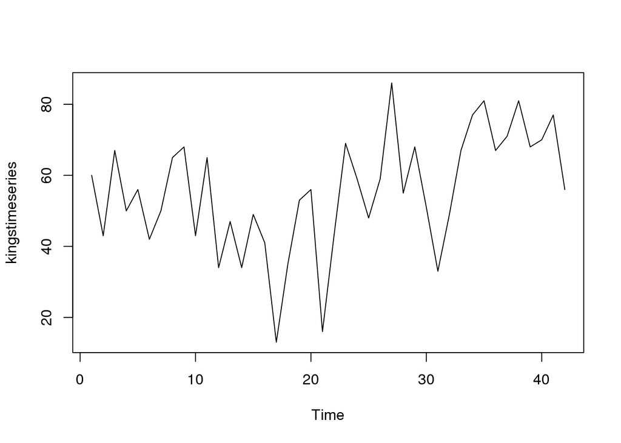

```r
plot.ts(kingstimeseries)
```

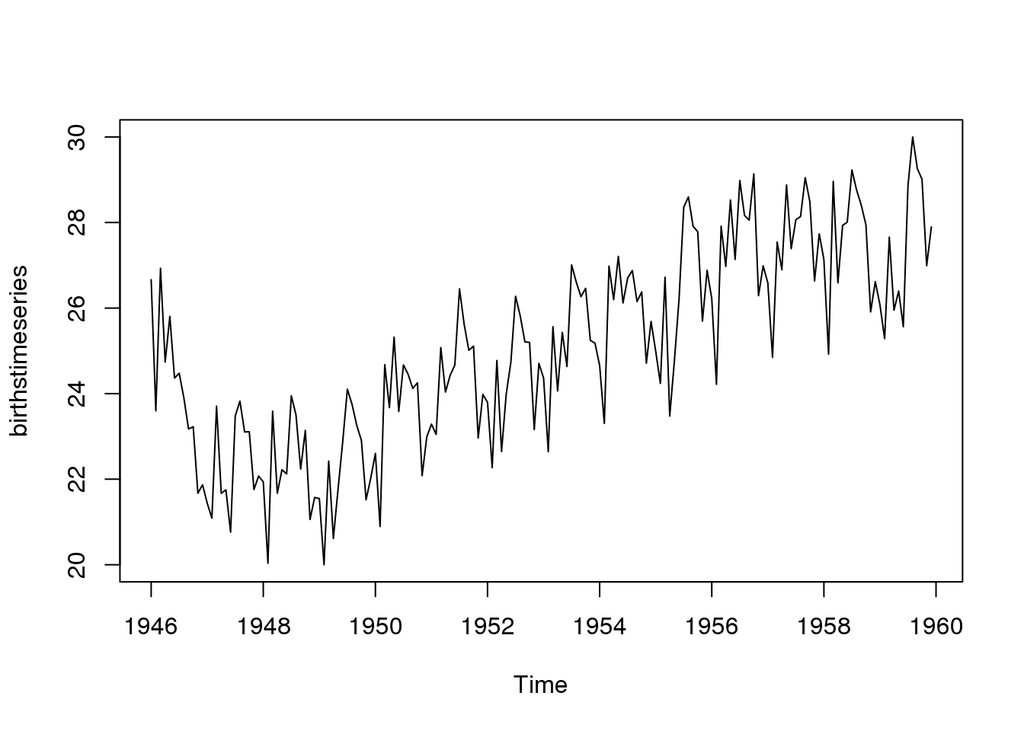

```r
plot.ts(birthstimeseries)
```

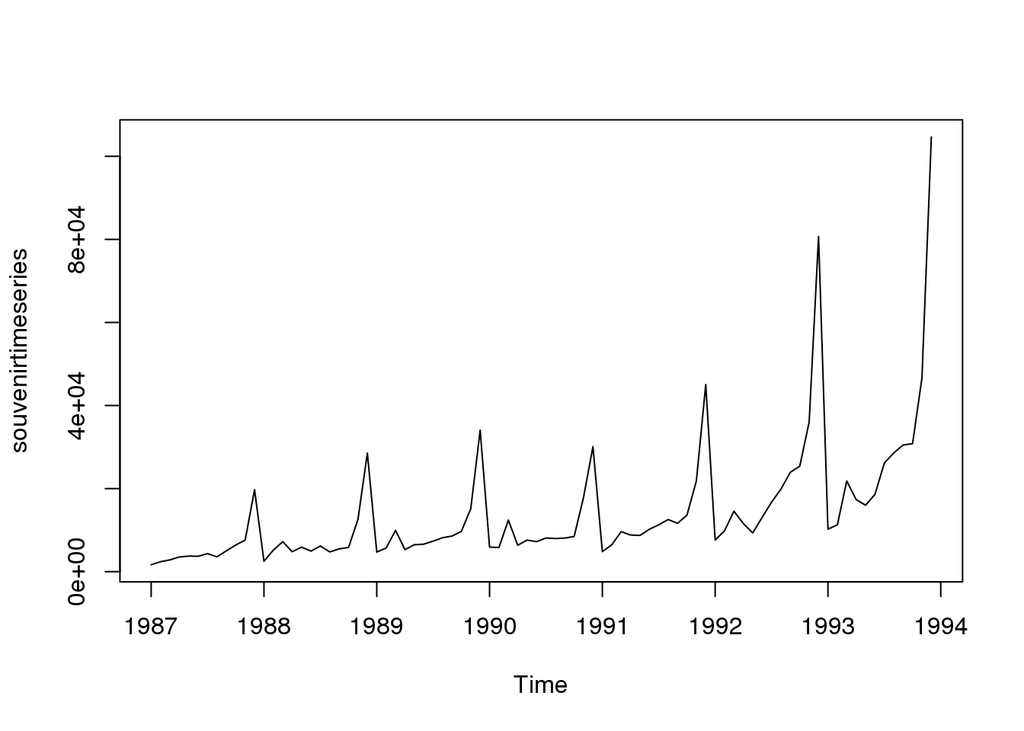

```r
plot.ts(souvenirtimeseries)
```

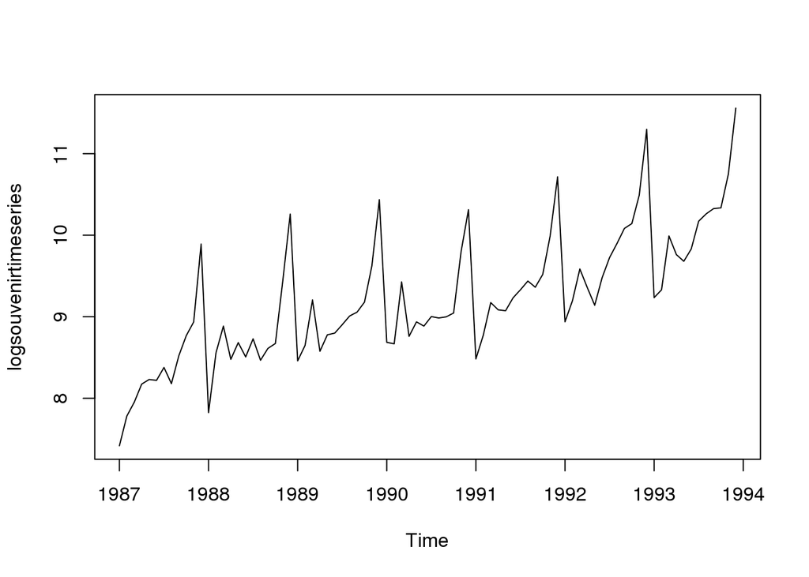

```r
# 从上面看第三个时序模型不适合用加性模型, 因为季节波动的部分随着时间也在放大
# 所以可以对上面纪念品商品的月销售额数据先做一些变换
logsouvenirtimeseries <- log(souvenirtimeseries)
plot.ts(logsouvenirtimeseries)
```

## 分解时间序列

### 分解非周期性数据

对于非周期性数据, 分解的工作就是将其分解成趋势部分和不规则变动部分. 对于可应用加性模型的非周期性时序数据, 要分解它的趋势部分, 通常可以使用平滑法, 比如使用常见的的移动平均值曲线来表示趋势部分. 移动平均可以使用 “TTR” 包中的 SMA() 函数来计算.

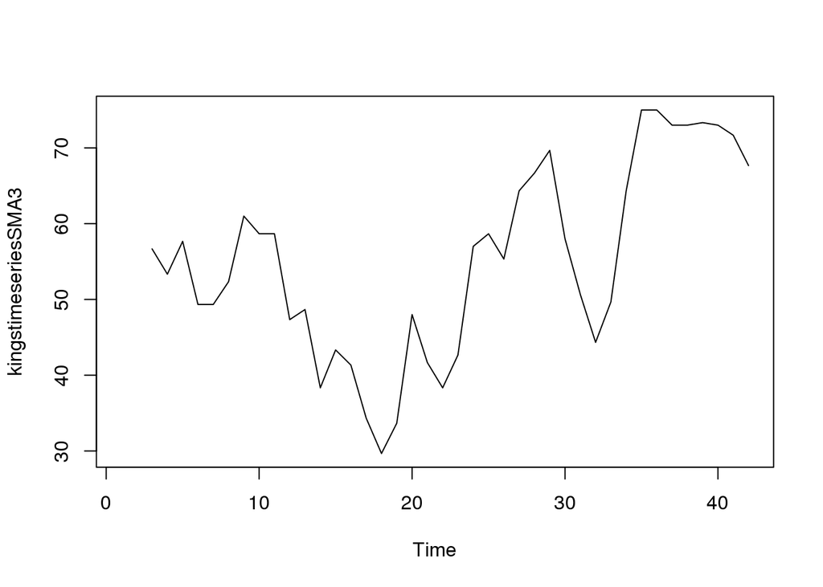

```r
library("TTR")
kingstimeseriesSMA3 <- SMA(kingstimeseries, n=3)
plot.ts(kingstimeseriesSMA3)
```

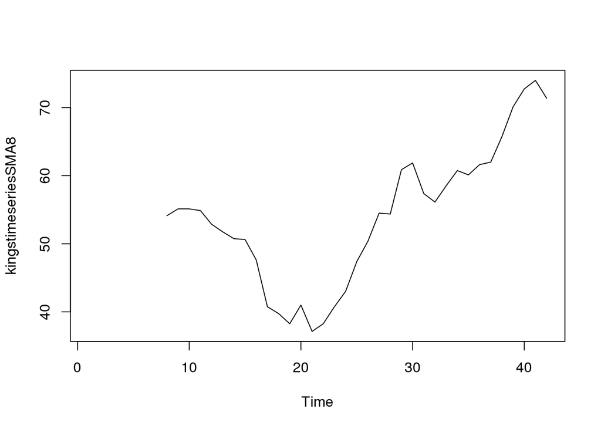

```r
kingstimeseriesSMA8 <- SMA(kingstimeseries, n=8)
plot.ts(kingstimeseriesSMA8)
```

### 分解季节性数据

季节性时序数据包含有三部分, 趋势部分, 周期性变化部分和不规则变化部分. 对于分解季节性数据可以使用 decompose() 函数, 该函数会返回一个对象列表, 会讲上面提到的三个部分分别存入 “seasonal”, “trend” 和 “random” 三个对象中.

```r
birthstimeseriescomponents <- decompose(birthstimeseries)
birthstimeseriescomponents$seasonal
```

```
##             Jan        Feb        Mar        Apr        May        Jun
## 1946 -0.6771947 -2.0829607  0.8625232 -0.8016787  0.2516514 -0.1532556
## 1947 -0.6771947 -2.0829607  0.8625232 -0.8016787  0.2516514 -0.1532556
## 1948 -0.6771947 -2.0829607  0.8625232 -0.8016787  0.2516514 -0.1532556
## 1949 -0.6771947 -2.0829607  0.8625232 -0.8016787  0.2516514 -0.1532556
## 1950 -0.6771947 -2.0829607  0.8625232 -0.8016787  0.2516514 -0.1532556
## 1951 -0.6771947 -2.0829607  0.8625232 -0.8016787  0.2516514 -0.1532556
## 1952 -0.6771947 -2.0829607  0.8625232 -0.8016787  0.2516514 -0.1532556
## 1953 -0.6771947 -2.0829607  0.8625232 -0.8016787  0.2516514 -0.1532556
## 1954 -0.6771947 -2.0829607  0.8625232 -0.8016787  0.2516514 -0.1532556
## 1955 -0.6771947 -2.0829607  0.8625232 -0.8016787  0.2516514 -0.1532556
## 1956 -0.6771947 -2.0829607  0.8625232 -0.8016787  0.2516514 -0.1532556
## 1957 -0.6771947 -2.0829607  0.8625232 -0.8016787  0.2516514 -0.1532556
## 1958 -0.6771947 -2.0829607  0.8625232 -0.8016787  0.2516514 -0.1532556
## 1959 -0.6771947 -2.0829607  0.8625232 -0.8016787  0.2516514 -0.1532556
##             Jul        Aug        Sep        Oct        Nov        Dec
## 1946  1.4560457  1.1645938  0.6916162  0.7752444 -1.1097652 -0.3768197
## 1947  1.4560457  1.1645938  0.6916162  0.7752444 -1.1097652 -0.3768197
## 1948  1.4560457  1.1645938  0.6916162  0.7752444 -1.1097652 -0.3768197
## 1949  1.4560457  1.1645938  0.6916162  0.7752444 -1.1097652 -0.3768197
## 1950  1.4560457  1.1645938  0.6916162  0.7752444 -1.1097652 -0.3768197
## 1951  1.4560457  1.1645938  0.6916162  0.7752444 -1.1097652 -0.3768197
## 1952  1.4560457  1.1645938  0.6916162  0.7752444 -1.1097652 -0.3768197
## 1953  1.4560457  1.1645938  0.6916162  0.7752444 -1.1097652 -0.3768197
## 1954  1.4560457  1.1645938  0.6916162  0.7752444 -1.1097652 -0.3768197
## 1955  1.4560457  1.1645938  0.6916162  0.7752444 -1.1097652 -0.3768197
## 1956  1.4560457  1.1645938  0.6916162  0.7752444 -1.1097652 -0.3768197
## 1957  1.4560457  1.1645938  0.6916162  0.7752444 -1.1097652 -0.3768197
## 1958  1.4560457  1.1645938  0.6916162  0.7752444 -1.1097652 -0.3768197
## 1959  1.4560457  1.1645938  0.6916162  0.7752444 -1.1097652 -0.3768197
```

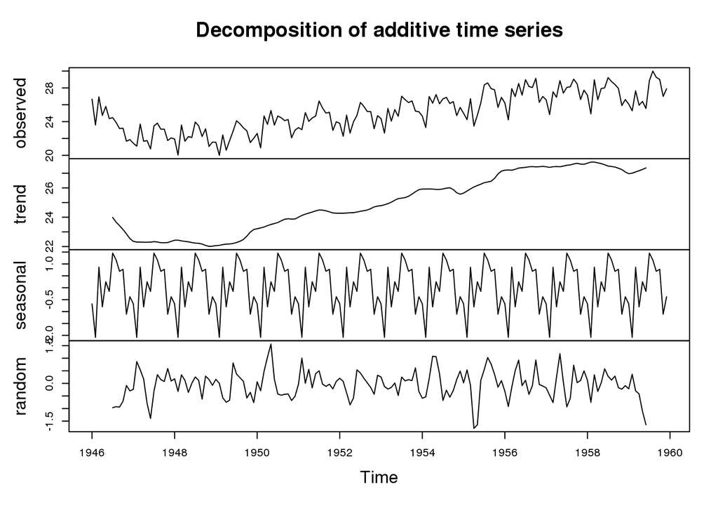

```r
plot(birthstimeseriescomponents)
```

## 用指数平滑来做预测

指数平滑可以用来对短期的时序数据做短期的预测.

### 简单指数平滑

如果有一个时间序列数据, 它可以用加性模型来描述, 保持固定的水平趋势并不带季节性, 那么你可以用简单的指数平滑法来做短期的预测.

下面是伦敦从 1813-1912 年每年总降雨量的英寸数.

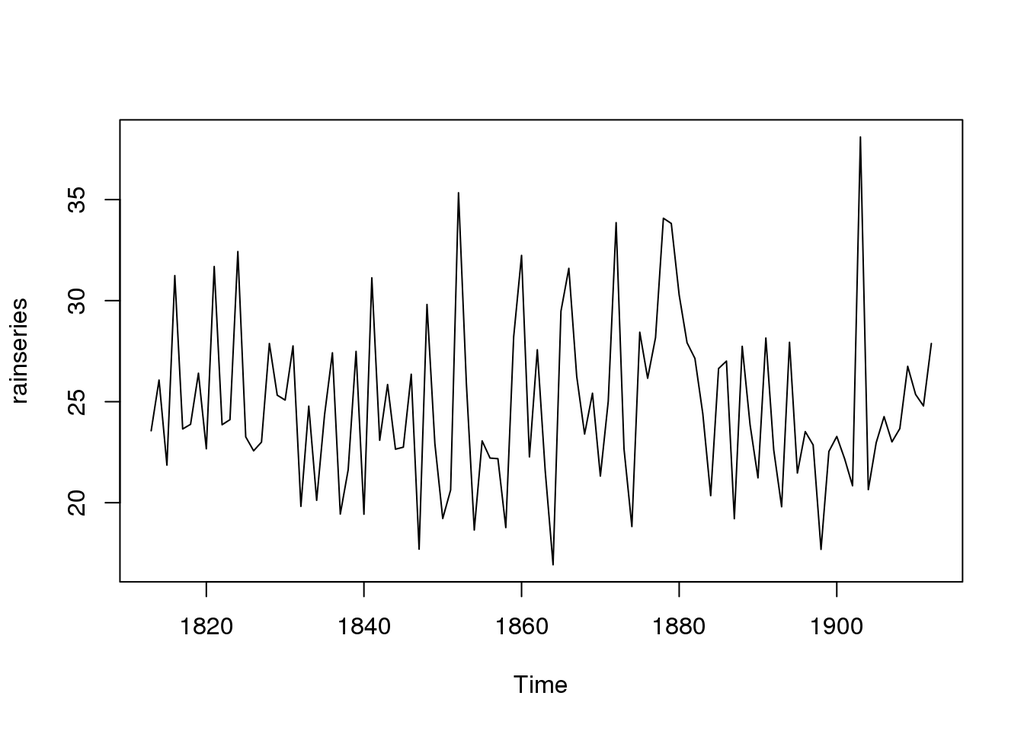

```r
rain <- scan("http://robjhyndman.com/tsdldata/hurst/precip1.dat", skip=1)
rainseries <- ts(rain, start=c(1813))
plot.ts(rainseries)
```

从上图中可以看出, 每年的降雨量大致保持在 25 英寸左右, 时间序列的随机部分大致保持在一个量级上, 所以是适用于加性模型的, 这样我们就可以用简单的指数平滑法来做预测.

在 R 中应用简单指数平滑法来做预测可以使用 HoltWinters() 函数. 用 HoltWinters() 做简单的指数平滑预测时需要设置参数 beta=FALSE 和 gamma=FALSE.

```r
rainseriesforecasts <- HoltWinters(rainseries, beta = FALSE, gamma = FALSE)
rainseriesforecasts
```

```
## Holt-Winters exponential smoothing without trend and without seasonal component.
##
## Call:
## HoltWinters(x = rainseries, beta = FALSE, gamma = FALSE)
##
## Smoothing parameters:
##  alpha: 0.02412151
##  beta : FALSE
##  gamma: FALSE
##
## Coefficients:
##       [,1]
## a 24.67819
```

```r
rainseriesforecasts$fitted
```

```
## Time Series:
## Start = 1814
## End = 1912
## Frequency = 1
##          xhat    level
## 1814 23.56000 23.56000
## 1815 23.62054 23.62054
## 1816 23.57808 23.57808
## 1817 23.76290 23.76290
## 1818 23.76017 23.76017
## 1819 23.76306 23.76306
## 1820 23.82691 23.82691
## 1821 23.79900 23.79900
## 1822 23.98935 23.98935
## 1823 23.98623 23.98623
```

[output cut: 89 more lines]

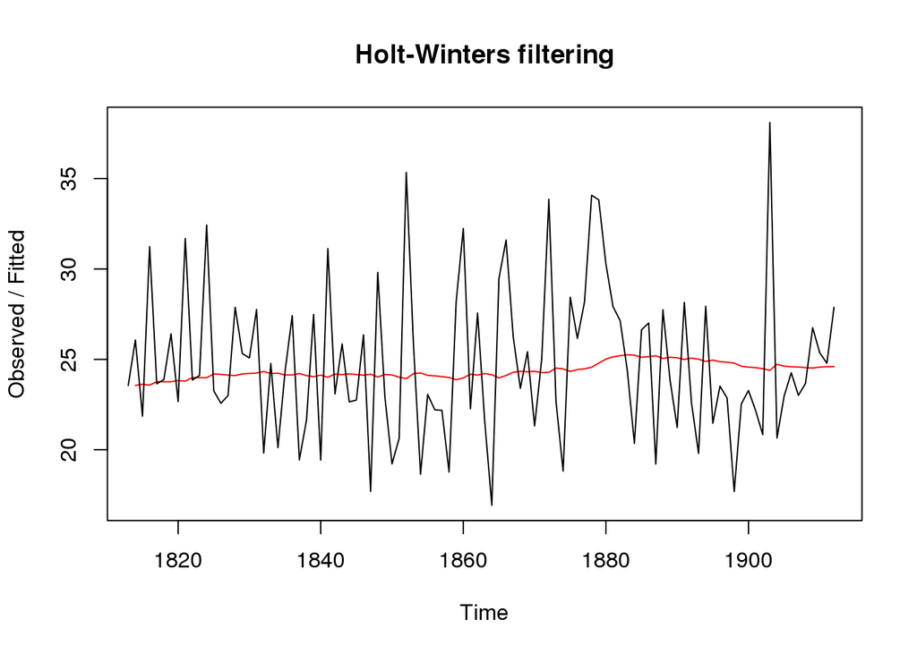

```r
plot(rainseriesforecasts)
```

上图中黑色曲线的是原始的时间序列数据, 红色的是预测值, 可以看出预测值比原始数据要平滑很多.

在做简单指数平滑法时经常使用时间序列的第一个值作为整个时序数据的水平值, 比如在上面的例子中, 就是使用 1813 年的降雨量 23.56 作为水平值, 在 HoltWinters() 函数中就是使用 l.start 参数来设置这个值, 如下.

```r
HoltWinters(rainseries, beta = FALSE, gamma = FALSE, l.start=23.56)
```

```
## Holt-Winters exponential smoothing without trend and without seasonal component.
##
## Call:
## HoltWinters(x = rainseries, beta = FALSE, gamma = FALSE, l.start = 23.56)
##
## Smoothing parameters:
##  alpha: 0.02412151
##  beta : FALSE
##  gamma: FALSE
##
## Coefficients:
##       [,1]
## a 24.67819
```

要使用 HoltWinters() 模型做对未来的预测需要使用 forecast 包的 forecast.HoltWinters() 函数, 通过参数 h 来指定要预测的点的个数. 预测函数会给出预测值以及相应的 80% 和 95% 置信区间的范围.

```r
library(forecast)
rainseriesforecasts2 <- forecast.HoltWinters(rainseriesforecasts, h=8)
rainseriesforecasts2
```

```
##      Point Forecast    Lo 80    Hi 80    Lo 95    Hi 95
## 1913       24.67819 19.17493 30.18145 16.26169 33.09470
## 1914       24.67819 19.17333 30.18305 16.25924 33.09715
## 1915       24.67819 19.17173 30.18465 16.25679 33.09960
## 1916       24.67819 19.17013 30.18625 16.25434 33.10204
## 1917       24.67819 19.16853 30.18785 16.25190 33.10449
## 1918       24.67819 19.16694 30.18945 16.24945 33.10694
## 1919       24.67819 19.16534 30.19105 16.24701 33.10938
## 1920       24.67819 19.16374 30.19265 16.24456 33.11182
```

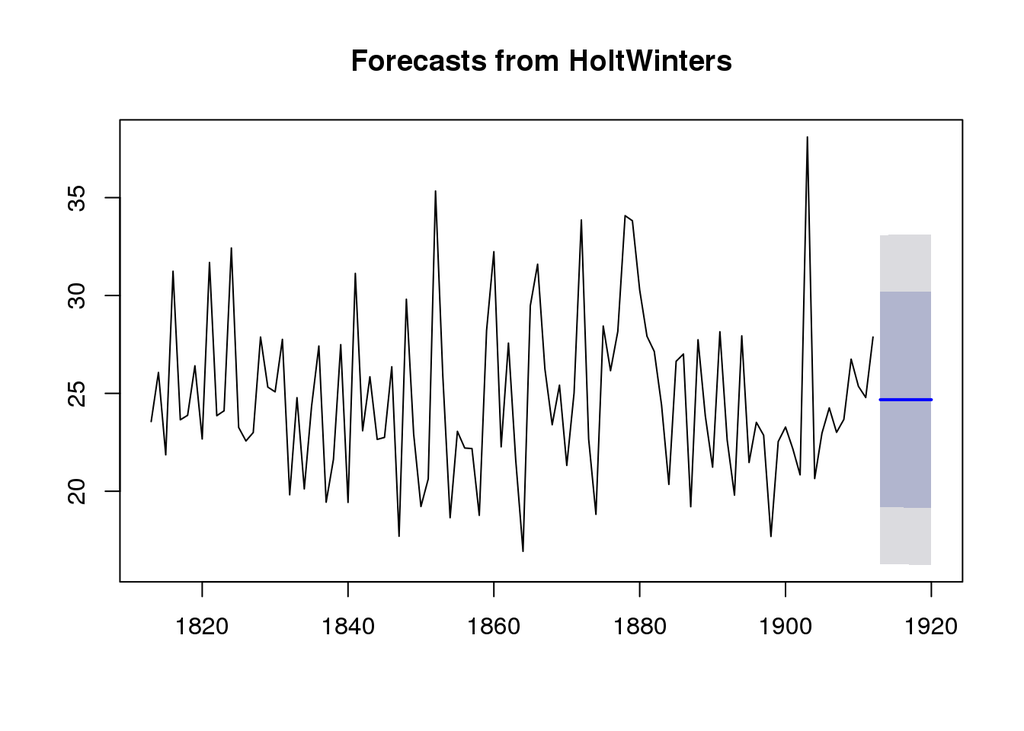

```r
plot.forecast(rainseriesforecasts2)
```

作为预测准确率的一个度量值, 可以调用 SSE (Sum of Squared errors)变量来查看, forecast.HoltWinters 函数的残数存在变量 residuals 中.

```r
rainseriesforecasts$SSE
```

```
## [1] 1828.855
```

```r
rainseriesforecasts2$residuals
```

```
## Time Series:
## Start = 1814
## End = 1912
## Frequency = 1
##  [1]  2.5100000 -1.7605450  7.6619220 -0.1128951  0.1198281  2.6469377
##  [7] -1.1569105  7.8909960 -0.1293468  0.1237733  8.4407877 -0.9328169
## [13] -1.6003159 -1.1317139  3.7755848  1.1245120  0.8573870  3.5167056
## [19] -4.5081227  0.5606200 -4.1129030  0.2063065  3.2813300 -4.7778206
## [25] -2.4725723  3.4470698 -4.6960787  7.1171978 -1.0944797  1.6919208
## [31] -1.5488909 -1.4115293  2.2325189 -6.4813328  5.7850067 -1.2345364
## [37] -4.9147575 -3.3862062 11.4054742  1.6803570 -5.6001757 -1.0550911
## [43] -1.8796407 -1.8643009 -5.2293312  4.3368082  8.2621979 -1.9070988
## [49]  3.4389033 -2.6240483 -7.2207523  5.5034232  7.4906723  1.9599860
## [55] -0.9372918  1.1053171 -3.0213449  0.7515345  9.5734064 -1.8475186
## [61] -5.6529537  4.1034041  1.7244238  3.6928281  9.5137515  9.0242655
## [67]  5.2665866  2.7795486  1.9325016 -0.8541132 -4.8835107  1.5242869
## [73]  1.8575188 -5.9872873  2.6871351 -1.2676827 -3.8571042  3.1559349
## [79] -2.4601910 -5.2108475  3.0548460 -3.4888415 -1.3546853 -1.9820083
## [85] -7.1041993 -2.0828352 -1.2925941 -2.3714148 -3.6442127 13.7036912
## [91] -4.0768625 -1.6585224 -0.3285164 -1.5705920 -0.8727070  2.2283440
## [97]  0.7845930  0.1956674  3.2809476
```

如果预测偏差的残数的前后相继值还有相关性, 就说明这个预测模型还有改进的余地, 为了验证是否存在这种情况, 我们选取 1-20 个时间间隔来计算相关性, 这个可以通过 acf() 函数来计算.

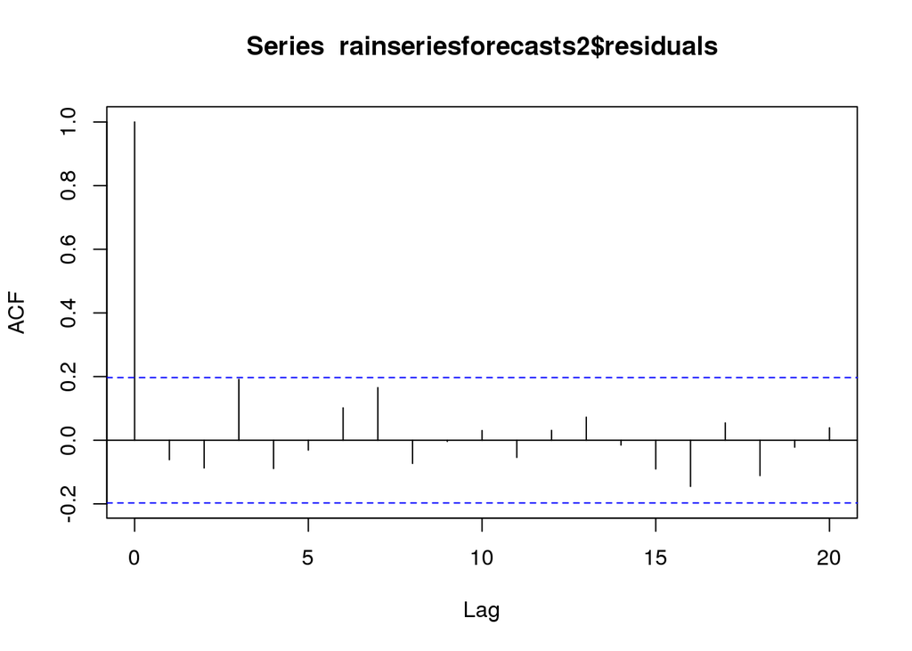

```r
acf(rainseriesforecasts2$residuals, lag.max = 20)
```

从上图中可以看到, 在间隔为 3 时自相关系数触到了显著性的警戒线. 为了进一步验证在时间间隔在 1-20 时是否存在非零的自相关系数的显著性证据, 我们可以使用 Ljung-Box 检验, 使用 Box.test() 函数来做这件事.

```r
Box.test(rainseriesforecasts2$residuals, lag=20, type="Ljung-Box")
```

```
##
##  Box-Ljung test
##
## data:  rainseriesforecasts2$residuals
## X-squared = 17.401, df = 20, p-value = 0.6268
```

此处 Ljung-Box 检验的统计量是 17.4, p 值是 0.6, 所以很难支撑说有非零的自相关性. 为了更好地说明这个预测已经没法更好地改进的时候, 去检验预测的残差是否满足期望为 0 方差稳定的正态分布也是个好办法, 下面通过定义函数 plotForecastErrors 来画出这样的图.

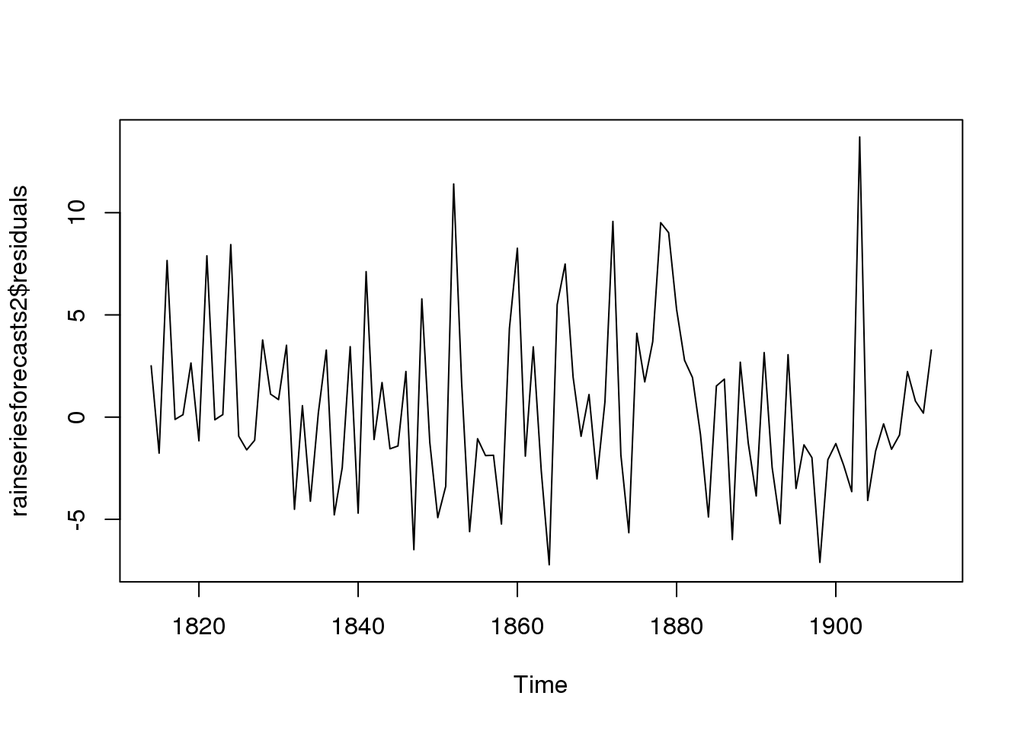

```r
plot.ts(rainseriesforecasts2$residuals)
```

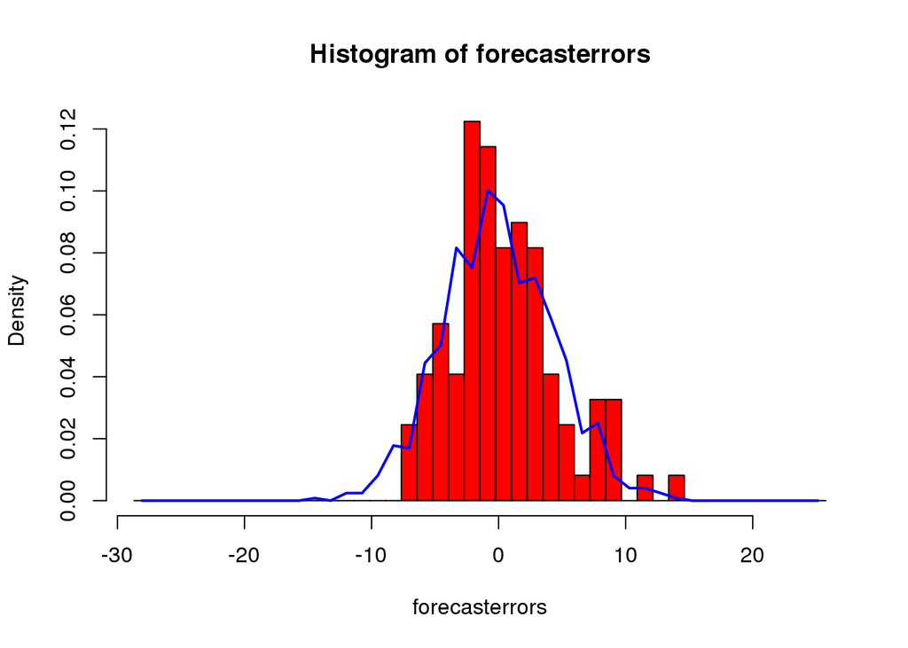

```r
plotForecastErrors <- function(forecasterrors)
{
  # 计算画预测误差的直方图所需的值
  mybinsize <- IQR(forecasterrors)/4
  mysd <- sd(forecasterrors)
  mymin <- min(forecasterrors) - mysd*5
  mymax <- max(forecasterrors) + mysd*3
  # 生成正态分布图, 期望为 0 , 方差和误差值的方差相同
  mynorm <- rnorm(1000, mean=0, sd=mysd)
  mymin2 <- min(mynorm)
  mymax2 <- max(mynorm)
  if (mymin2 < mymin) { mymin <- mymin2 }
  if (mymax2 > mymax) { mymax <- mymax2 }
  #
  mybins <- seq(mymin, mymax, mybinsize)
  hist(forecasterrors, col="red", freq=FALSE, breaks=mybins)
  myhist <- hist(mynorm, plot=FALSE, breaks=mybins)
  points(myhist$mids, myhist$density, type="l", col="blue", lwd=2)
}

plotForecastErrors(rainseriesforecasts2$residuals)
```

上图显示预测的误差值大致符合正态分布, 小幅右偏. 所以从上面的 Ljung-Box 检验和误差值的正态分布值的图形都可以看出, 简单指数平滑法在预测伦敦的年降雨量是适用的, 并且没有更好的改进方法.

### Holt 指数平滑

如果时间序列能用加性模型, 有上升或者下降趋势, 但是没有周期性波动, 可以应用 Holt 指数平滑法做短期的预测. 这个模型的预测由参数 alpha 和 beta 控制, beta 参数是和趋势的斜率有关, 两个参数的取值都在 0,1 之间.

下面是适用带趋势的加性模型且没有周期性的时间序列数据, 取得是从 1866-1911 每年的女性裙子的直径长度的数据.

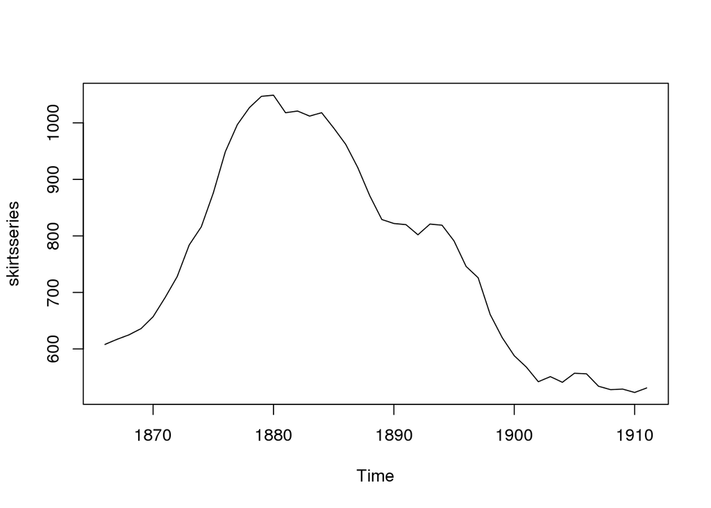

```r
skirts <- scan("http://robjhyndman.com/tsdldata/roberts/skirts.dat", skip=5)
skirtsseries <- ts(skirts, start=c(1866))
plot.ts(skirtsseries)
```

```r
skirtsseriesforecasts <- HoltWinters(skirtsseries, gamma=FALSE)
skirtsseriesforecasts
```

```
## Holt-Winters exponential smoothing with trend and without seasonal component.
##
## Call:
## HoltWinters(x = skirtsseries, gamma = FALSE)
##
## Smoothing parameters:
##  alpha: 0.8383481
##  beta : 1
##  gamma: FALSE
##
## Coefficients:
##         [,1]
## a 529.308585
## b   5.690464
```

从上面可以看出 alpha 的值为 0.84, beta 的值为 1, 这两个值都离 1 很近, 说明预测值对最新的值的依赖度很高. 下面将画出实际值和预测值, 预测值用红色线表示.

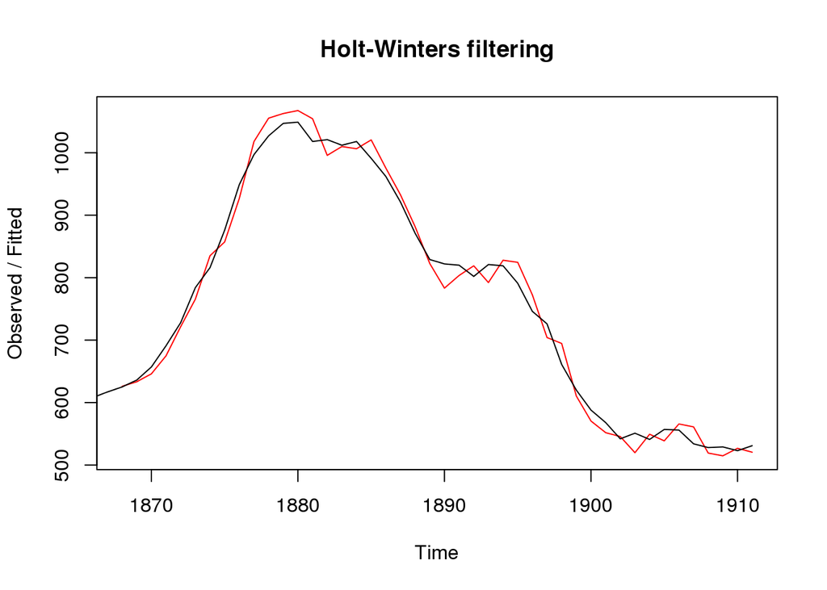

```r
plot(skirtsseriesforecasts)
```

一般地还可以指定初始值, 在上面这个例子中, 初始点就是 1866 年的裙长 608, 斜率的初始值为第二个时间点的值减掉第一个点的值, 在此处是 9.

```r
HoltWinters(skirtsseries, gamma = FALSE, l.start = 608, b.start = 9)
```

```
## Holt-Winters exponential smoothing with trend and without seasonal component.
##
## Call:
## HoltWinters(x = skirtsseries, gamma = FALSE, l.start = 608, b.start = 9)
##
## Smoothing parameters:
##  alpha: 0.8346775
##  beta : 1
##  gamma: FALSE
##
## Coefficients:
##         [,1]
## a 529.278637
## b   5.670129
```

用 Holt 模型来做预测, 同样的, 会有 80% 和 95% 置信区间.

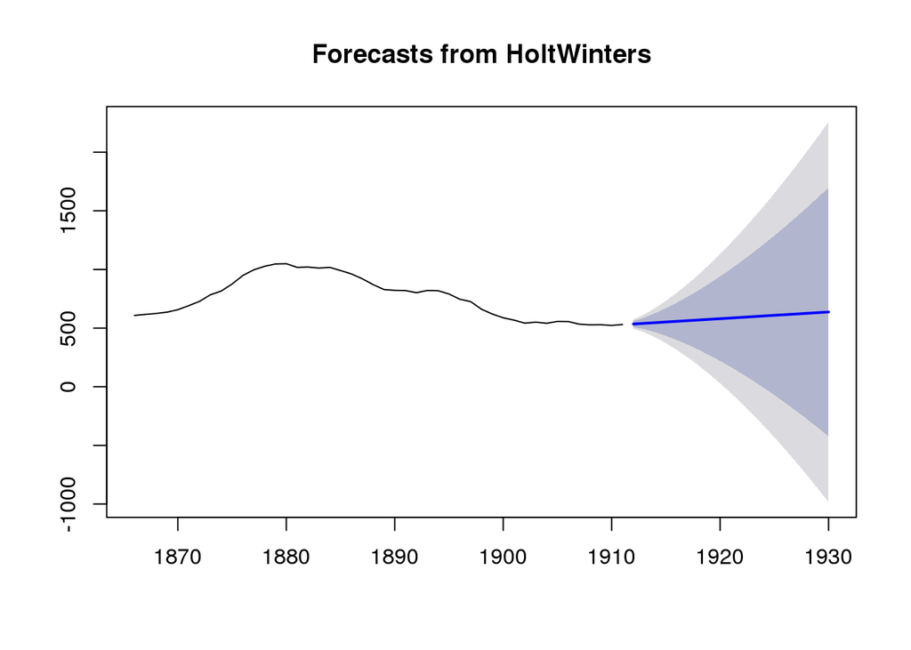

```r
skirtsseriesforecasts2 <- forecast.HoltWinters(skirtsseriesforecasts, h=19)
plot.forecast(skirtsseriesforecasts2)
```

同样地, 做 Ljung-Box 检验, 检验误差的自相关性.

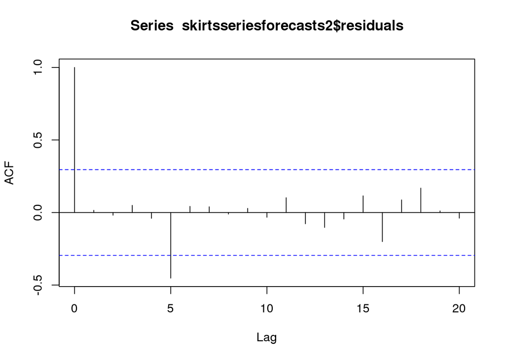

```r
acf(skirtsseriesforecasts2$residuals, lag.max = 20)
```

```r
Box.test(skirtsseriesforecasts2$residuals, lag = 20, type = "Ljung-Box")
```

```
##
##  Box-Ljung test
##
## data:  skirtsseriesforecasts2$residuals
## X-squared = 19.731, df = 20, p-value = 0.4749
```

从上面可以看出, 在延迟为 5 时自相关性超过了警戒值, 但是从 Ljung-Box 检验中没有自相关性为非 0 的显著性的支持. 对残差做正态性分布分析.

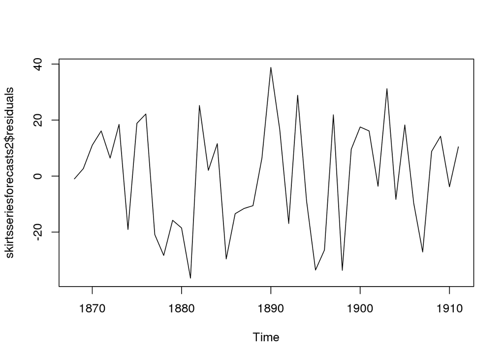

```r
plot.ts(skirtsseriesforecasts2$residuals)
```

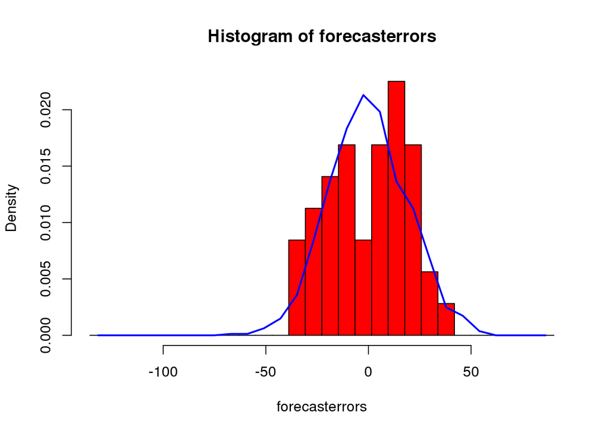

```r
plotForecastErrors(skirtsseriesforecasts2$residuals)
```

### Holt-Winters 指数平滑法

用于可用加性模型, 有趋势并带有季节波动的时间序列数据, 可以使用 Holt-Winters 指数平滑法来做短期的时间预测. 改算法使用介于 0,1 之间的三个参数, alpha, beta, gamma 来控制当前点的水平值, 斜率和季节性部分.

下面使用澳大利亚昆士兰一个度假海岸的纪念品商店的月销售数据来做解释.

```r
logsouvenirtimeseries <- log(souvenirtimeseries)
souvenirtimeseriesforecasts <- HoltWinters(logsouvenirtimeseries)
souvenirtimeseriesforecasts
```

```
## Holt-Winters exponential smoothing with trend and additive seasonal component.
##
## Call:
## HoltWinters(x = logsouvenirtimeseries)
##
## Smoothing parameters:
##  alpha: 0.413418
##  beta : 0
##  gamma: 0.9561275
##
## Coefficients:
##            [,1]
## a   10.37661961
## b    0.02996319
## s1  -0.80952063
## s2  -0.60576477
## s3   0.01103238
## s4  -0.24160551
## s5  -0.35933517
## s6  -0.18076683
## s7   0.07788605
## s8   0.10147055
## s9   0.09649353
## s10  0.05197826
## s11  0.41793637
## s12  1.18088423
```

```r
souvenirtimeseriesforecasts$SSE
```

```
## [1] 2.011491
```

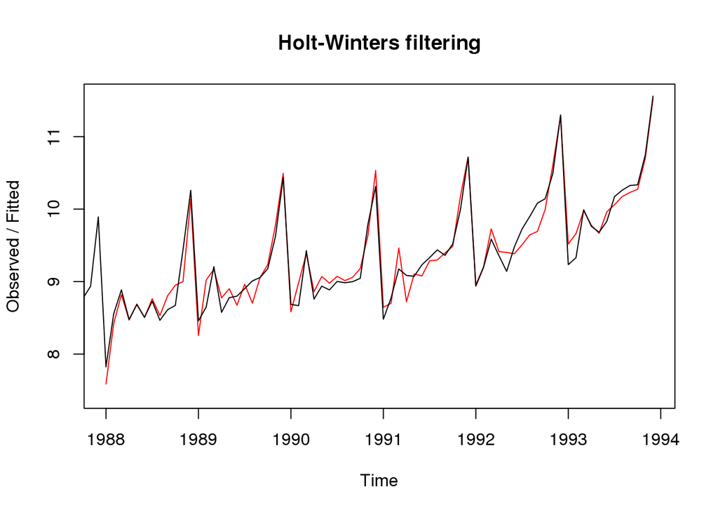

```r
plot(souvenirtimeseriesforecasts)
```

上面的计算结果显示 alph, beta, gamma 分别为 0.41, 0, 0.96. 预测未来的值要使用 forecast 包中的 forecast.HoltWinters() 函数.

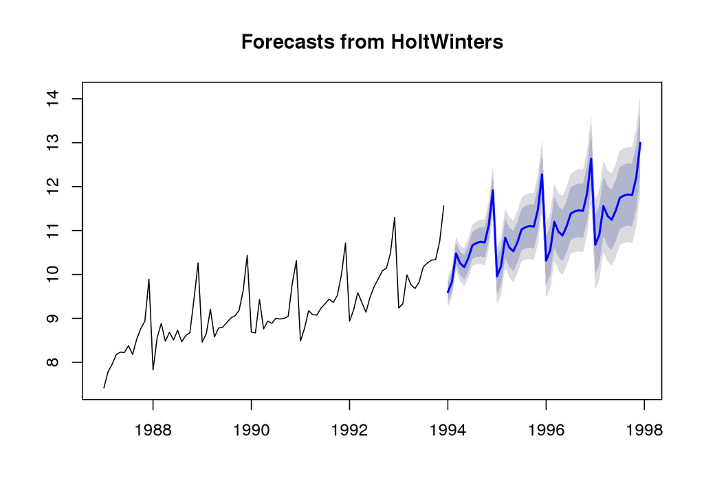

```r
library(forecast)
souvenirtimeseriesforecasts2 <- forecast.HoltWinters(souvenirtimeseriesforecasts, h=48)
plot.forecast(souvenirtimeseriesforecasts2)
```

同样的, 下面做检验

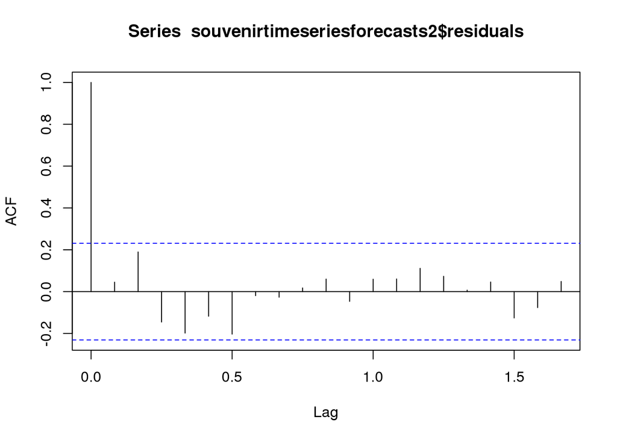

```r
acf(souvenirtimeseriesforecasts2$residuals, lag.max = 20)
```

```r
Box.test(souvenirtimeseriesforecasts2$residuals, lag=20, type="Ljung-Box")
```

```
##
##  Box-Ljung test
##
## data:  souvenirtimeseriesforecasts2$residuals
## X-squared = 17.53, df = 20, p-value = 0.6183
```

下面做残差图

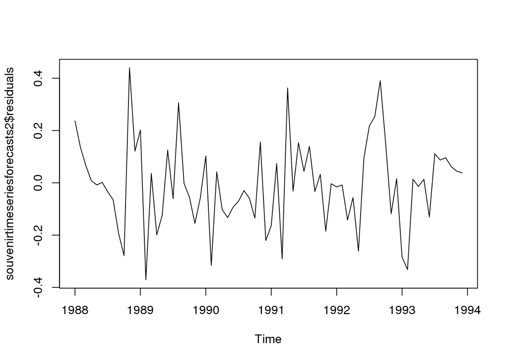

```r
plot.ts(souvenirtimeseriesforecasts2$residuals)
```

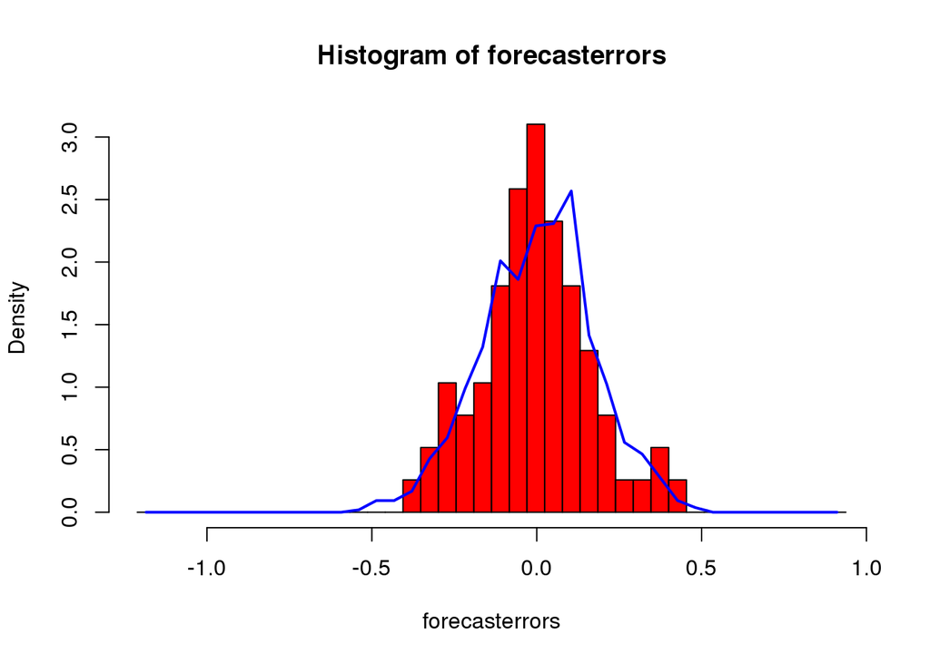

```r
plotForecastErrors(souvenirtimeseriesforecasts2$residuals)
```

## ARIMA 模型

指数平滑法在做预测的时候很有用, 它不用假设相连数据的相关性, 但是, 当你需要用它做一段时间的预测的时候, 需要在预测区间的误差无自相关性并且误差满足期望为 0 方差为常值的正态分布.

指数平滑法不需要假设数据有自相关性, 但是有时候我们可以更好地利用数据的自相关性来改进预测. Autoregressive Integrated Moving Average (ARIMA) 模型包含一个对时间序列无规则的部分的显式统计模型, 这个允许不规则部分有非零的自相关性.

对 1866-1911 年的女性裙长的数据应用 ARIMA 模型

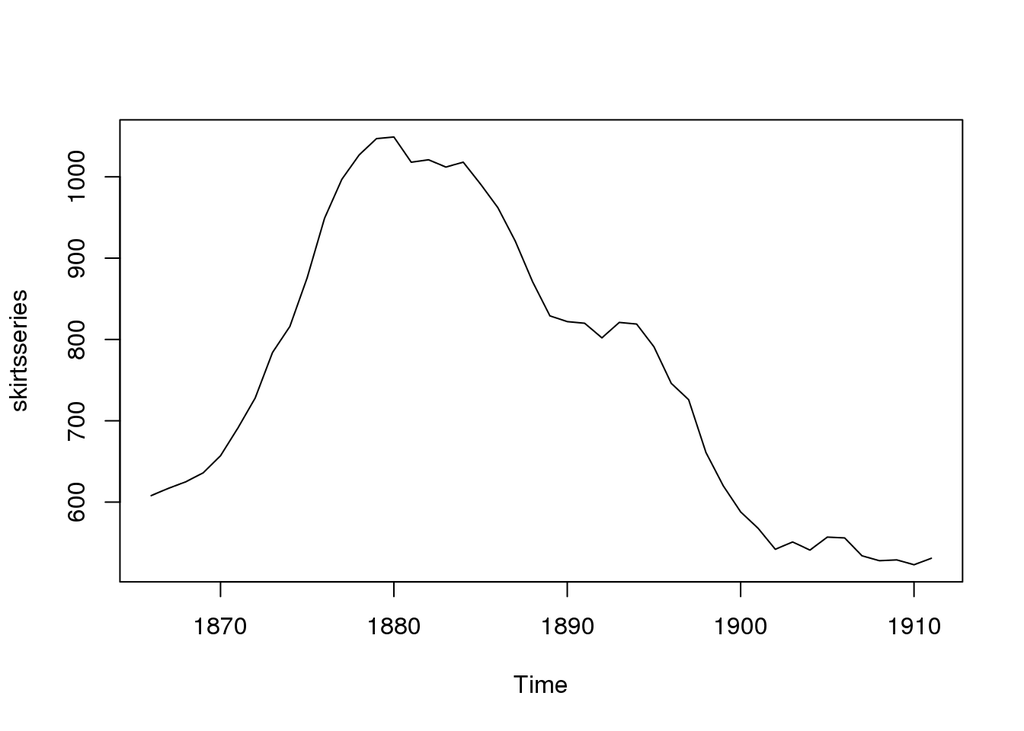

```r
plot.ts(skirtsseries)
```

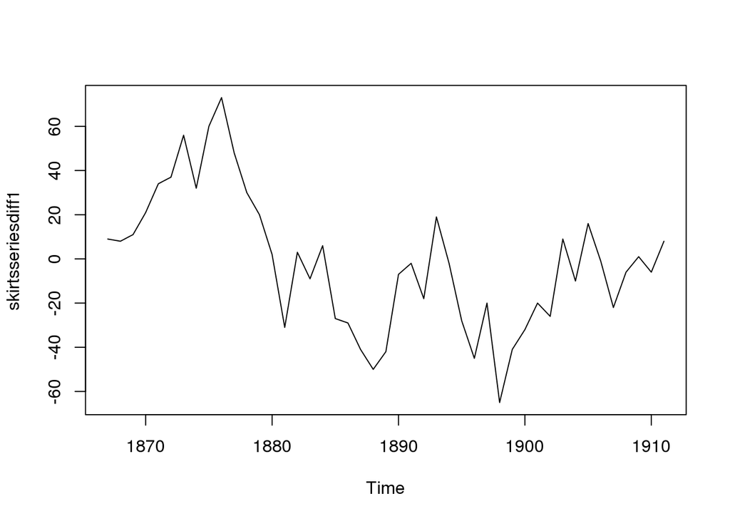

```r
skirtsseriesdiff1 <- diff(skirtsseries, differences = 1)
plot.ts(skirtsseriesdiff1)
```

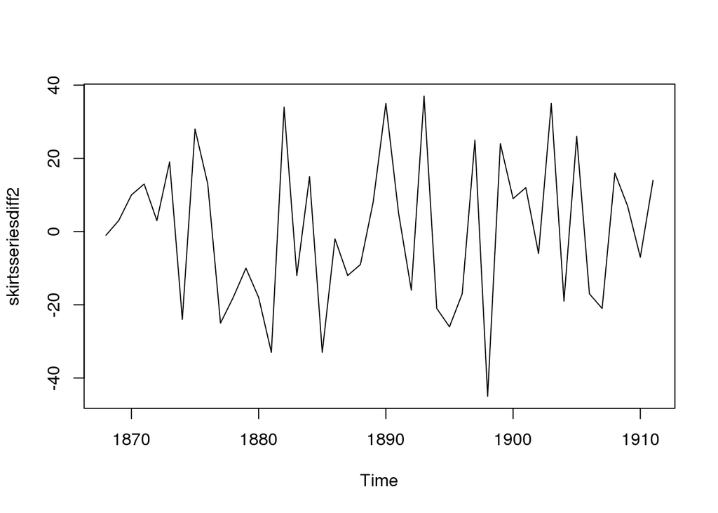

```r
skirtsseriesdiff2 <- diff(skirtsseries, differences = 2)
plot.ts(skirtsseriesdiff2)
```

做二阶的差分后时序数据已经保持稳定, 对于稳定性的检测可以使用“单位根检验”(unit root tests), 相应的 R 包 fUnitRoots. 下面国王的时序数据做一阶差分就稳定.

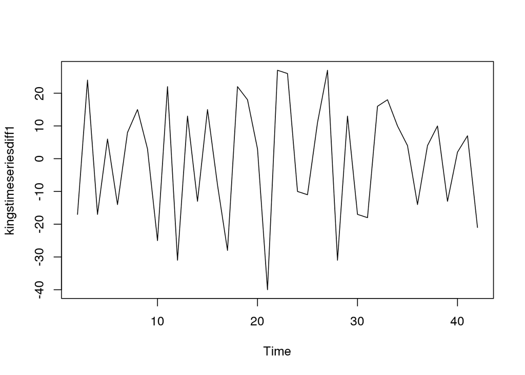

```r
kingstimeseriesdiff1 <- diff(kingstimeseries, differences = 1)
plot.ts(kingstimeseriesdiff1)
```

计算自相关和偏自相关的系数, 可以使用 R 中的 acf() 和 pacf() 函数来计算, 通过设置参数 plot=FALSE 来得到具体的数值.

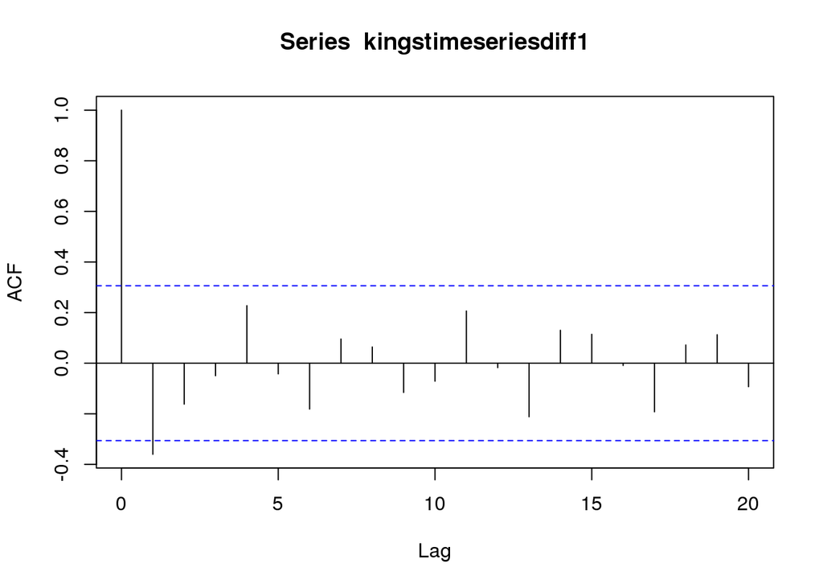

```r
acf(kingstimeseriesdiff1, lag.max = 20)
```

```r
acf(kingstimeseriesdiff1, lag.max = 20, plot = FALSE)
```

```
##
## Autocorrelations of series 'kingstimeseriesdiff1', by lag
##
##      0      1      2      3      4      5      6      7      8      9
##  1.000 -0.360 -0.162 -0.050  0.227 -0.042 -0.181  0.095  0.064 -0.116
##     10     11     12     13     14     15     16     17     18     19
## -0.071  0.206 -0.017 -0.212  0.130  0.114 -0.009 -0.192  0.072  0.113
##     20
## -0.093
```

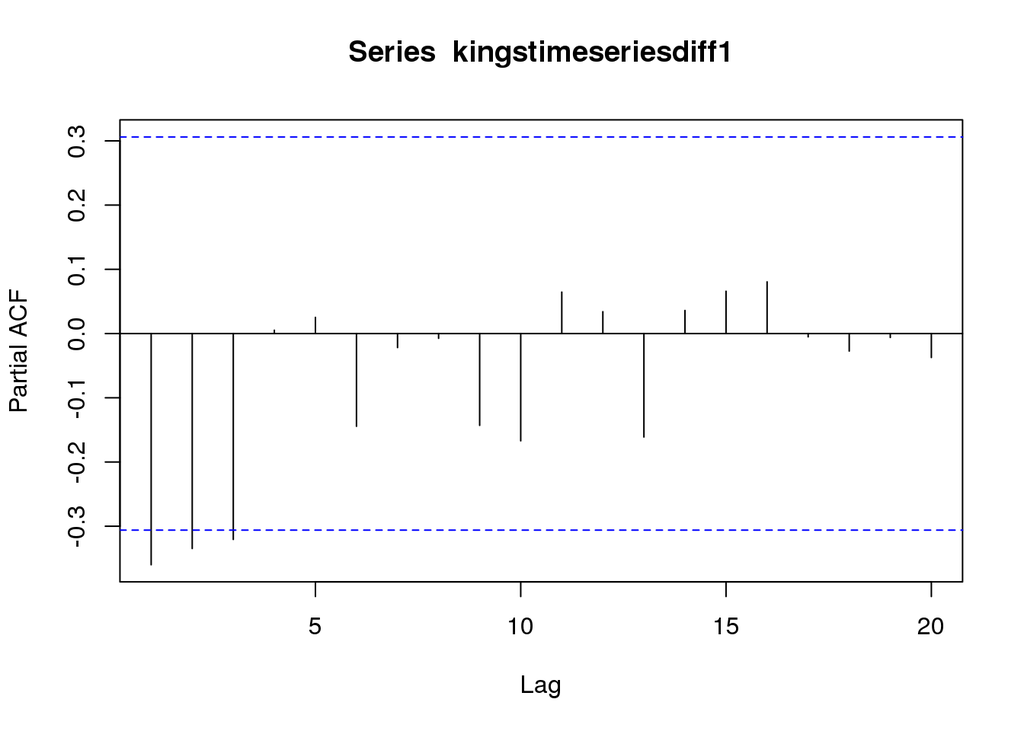

```r
pacf(kingstimeseriesdiff1, lag.max = 20)
```

```r
pacf(kingstimeseriesdiff1, lag.max = 20, plot = FALSE)
```

```
##
## Partial autocorrelations of series 'kingstimeseriesdiff1', by lag
##
##      1      2      3      4      5      6      7      8      9     10
## -0.360 -0.335 -0.321  0.005  0.025 -0.144 -0.022 -0.007 -0.143 -0.167
##     11     12     13     14     15     16     17     18     19     20
##  0.065  0.034 -0.161  0.036  0.066  0.081 -0.005 -0.027 -0.006 -0.037
```

参考: 1. [A Little Book of R For Time Series](http://a-little-book-of-r-for-time-series.readthedocs.org/en/latest/)